# Coursework Report

*N* removed NAs: 2

*N* removed typo: 1

*N* removed <18: 18

*N* total clean: 129

| Group | *N* | *M*<sub>age</sub> | *M*<sub>rating</sub> |
| --- | --- | --- | --- |
| Control | 67 | 21.55 | 5.83 |
| Experim | 62 | 20.63 | 6.26 |

**Main analysis results**

*t*(127) = -3.06, *p* = .003

[interactive chart not shown]

[figure not shown]

[interactive chart not shown]

# Coursework Report

Analysing Data, Spring 2020

# Methods

## Participants

This study aimed to explore whether women find men more attractive in conjunction with the colour red. The study initially had 150 participants, ranging from age 2 to 26, and with a mean age of 20.27 years old. The standard deviation of the initial participants ages can be calculated to 3.37. The answers of 21 participants were removed from the study, 19 participants because they were younger than 18 years old, and 2 because they neglected to state their age. This meant that the final results were calculated from the answers of 129 participants.

*Figure.1* Descriptive statistics of ages by condition

| Condition | *N* | *M*<sub>age</sub> | *SD*<sub>age</sub> | *Min*<sub>age</sub> | *Max*<sub>age</sub> |
| --- | --- | --- | --- | --- | --- |
| White | 67 | 21.55 | 2.12 | 18 | 26 |
| Red | 62 | 20.63 | 2.02 | 18 | 26 |

## Design

This study is a replication of a study by Elliot et al (2010) that hypothesised that women will find men more attractive in conjunction with the colour red. The study split participants into two groups, the control group saw a picture of a man in a white frame, the experimental group saw him in a red frame. The participants were then asked to rate how attractive the man was. According to the hypothesis, the women would rate the photo of the man surrounded by red as more attractive.

A variable for this study was what colour frame the photo of the man was in, red or white. This variable was an independent categorical variable which had two components: red or white. The dependent variable for this study was how attractive the women rated the man. This factor was a continuous variable that was measured by a scale of 1 to 10. 1 was the lowest rating they could be given, meaning he was rated unattractive and 10 was the highest score, meaning he was very attractive. The participants were asked 3 different questions they had to rate the man on. Question 1: how attractive do you think this person is? Question 2: how pleasant is this person to look at? Question 3: if I were to meet this person face to face, I would think he is attractive. The participants answered all the questions giving the rating of 1-10 and then an average of all of their answers was calculated.  
Another variable to consider are the age of the participants. This variable is a factor that could influence attractiveness rating as a woman could rate the man more attractive if they are close in age.

The conceptual hypothesis for this study is: does colour influence attractiveness? The operational hypothesis of this experiment would be: does viewing the same picture of a man surrounded by a red background as opposed to a white background result in him being given a higher mean attractiveness rating?

To analyse the results of this experiment, the results will be analysed using a two sample t-test as the mean of two samples, results from the red condition and the white condition, need to be analysed.

# Results

There were several things about the data that had to be changed. Firstly, the age of the participants were mutated and changed into numeric numbers, this is so they can be easily put into the tables. Secondly, the participants were filtered and all participants that stated they were under 18 years old, or refused to give their age, were removed. This is because asking underage people how attractive they found men would be inappropriate, and because people over 18 years old would give the most reliable ratings. Additional changes to the data include changing the names of the groups from ‘contrl’ and ‘expermentl’ to ‘red’ and ‘white’. This was done to make the data easier to interpret and so it would look more professional in graphs that were created. Lastly, the ratings of attractiveness that were given by participants were mutated into numeric format so they could be analysed using statistical analysis and so they would be added to graphs.

The general pattern of results shows that the participants consistently rated the photo of the man in the red frame more attractive than the white frame. This finding is in line with the original study, where Elliot et al (2010) also noted that the men were rated as more attractive in the red condition than the white. Upon closer inspection it becomes clear that the participants gave the man in the red frame a mean higher attractiveness score for all the questions. They said that the photo of the man surrounded by red is more attractive, more pleasant to look at, and would be more likely to find him attractive face to face. The results of the study prior to statistical analysis suggest that women do find men more attractive in conjunction with the colour red.

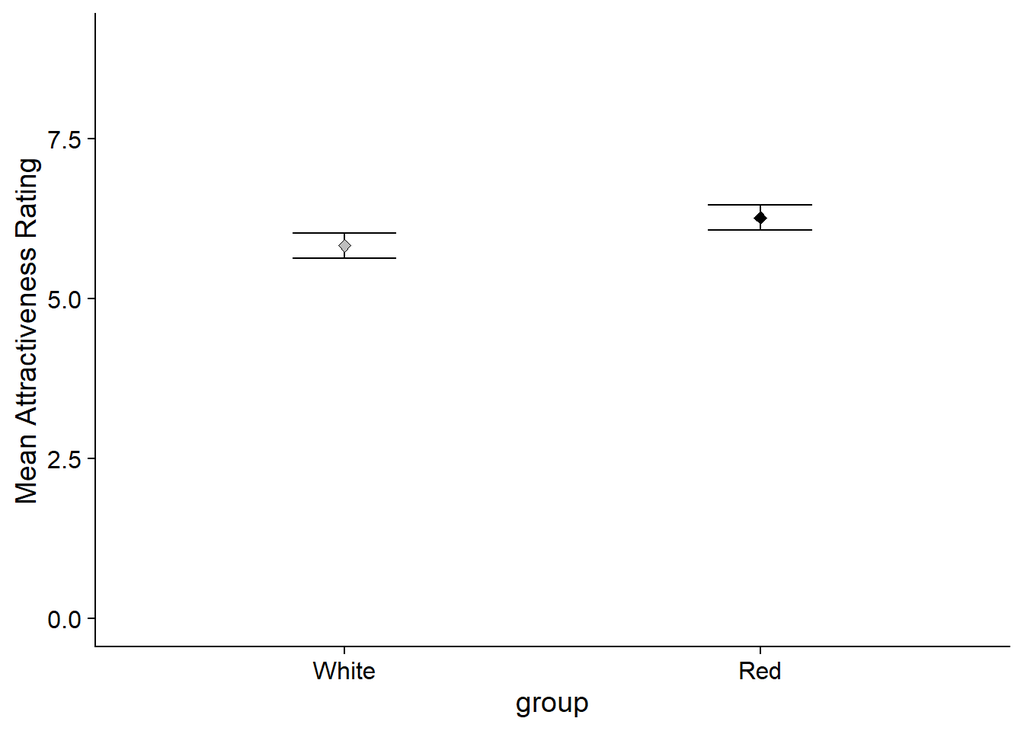

**Mean Attractiveness Plot**

We investigated whether participants would rate men as more attractive in conjunction with the colour red, using an independent-measures *t*-test. The analysis indicated that, as predicted, men surrounded by white were given lower mean ratings of attrctiveness (*M* = 5.83) than men surrounded by red (*M* = 6.26). This difference in means was significant (*M*<sub>diff</sub> = -0.44, 95% CI [-0.72, -0.15], *t* (127) = -3.06, *p* = 0.003 ).

The results of this t-test are statistically significant, showing that the seen effect is large enough to conclude that the women found the man surrounded by red more attractive than the same man surrounded by white. This gives evidences towards the argument that the colour red influences romantic attraction.

# Discussion

Overall, the results of this study suggest that the colour red does influence romantic attraction to men. This can be seen as the participants give the man a high mean attractiveness score across all questions in the red condition. Additionally, the statistical t-test that was performed on the results stated that they were statistically significant, suggesting that there was enough of a difference between the two groups to support the argument that red influences romantic attraction.

In the original study by Elliot et al (2010), it was concluded that the colour red does influence women’s romantic attraction to men. However, the original study was a lot larger and so used three different male models, it also used a combination of different colour frames and different colour shirts. Additionally, Elliot et al (2010) was not only focused on female romantic attraction to men but also on men’s perception of other men, likability, agreeableness, and extraversion. This study contributes to the research area as it got the same pattern of results, that red affects women’s romantic attraction to men, but it is more reliable as this study was focused specifically on romantic attraction and so had less variables. These two studies provide critical evidence to the argument hat red influences how women are attracted to men.

Additionally, Elliot (2008) concluded that red also influences men’s romantic attraction to women, evidence for this was also found by Kayser (2010), and Schwarz (2013), who stated that red influences romantic attraction towards young women but not women of menopausal age. Whilst these finding focus on male attraction to female, it is the same pattern of results that suggest that the colour red can make people be rated as more attractive. However, other studies have concluded that the colour red does not influence romantic attraction. A good example of such a study is from Peperkoorn (2016), who stated that there was no significant evidence that red has an effect. The majority of studies investigating the effect of how the colour red influences romantic attraction concluded that there is a seen effect. However, most of these studies were looking specially at how men view women or, like Elliot (2010) were looking at a variety of effects of the colour red, not just romantic attraction. From this evidence, it can be concluded that the colour red does influence the first impressions given by a person but whether that impression is based solely on romantic attraction, and whether it applies to everyone still needs more evidence.

Strengths of this study include the fact that it was focused on romantic attraction and so had few variables that could affect the results. Limitations of this study include the small sample size and the small age range of participants. Based on this study, along with supporting evidence from other papers such as Elliot (2010) it can be concluded that women view men as more attractive in conjunction with the colour red. However, these results can only be applied to heterosexual women ages 18-26, a very small sample of the population. In order to see the effect on the whole population, a much larger scale study would need to be conducted that has a larger range of participant ethnicities, ages, and sexualities.

This research question would benefit from a lot more research. As previously mentioned, a large-scale study would need to be conducted in order to see the effect of the colour red on the whole population. However, there are many different branches of this hypothesis to be explored. For example, does the colour red influence homosexual couples? This study could be done on homosexual men or women to see if it is applicable to the LGBT community. Additionally, it would be interesting to look and bi and pansexual individuals to see if the colour red influences their attraction to one gender but not the other. Overall, this research question needs to be investigated in a way that is much more representative of the wider population, looking at all genders, ages, ethnicities, personalities, and sexualities.

To conclude, this study hypothesised that the colour red would have a positive influence of women’s attraction to men and the hypothesis was proved correct. However, as the study had a small sample size, this effect can only be applied to heterosexual females aged 18-26 and further studies with samples more representative of the population would be needed to look at the population wide effect of the colour red on romantic attraction.

# References

- Elliot, A. J., Niesta Kayser, D., Greitemeyer, T., Lichtenfeld, S., Gramzow, R. H., Maier, M. A., & Liu, H. (2010). Red, rank, and romance in women viewing men. *Journal of Experimental Psychology: General, 139(3)*, 399.
- Elliot, A. J., & Niesta, D. (2008). Romantic red: Red enhances men’s attraction to women. *Journal of personality and social psychology, 95(5)*, 1150.
- Niesta Kayser, D., Elliot, A. J., & Feltman, R. (2010). Red and romantic behavior in men viewing women. *European Journal of Social Psychology, 40(6)*, 901-908.
- Peperkoorn, L. S., Roberts, S. C., & Pollet, T. V. (2016). Revisiting the red effect on attractiveness and sexual receptivity: No effect of the color red on human mate preferences. *Evolutionary Psychology, 14(4)*, 1474704916673841.
- Schwarz, S., & Singer, M. (2013). Romantic red revisited: Red enhances men’s attraction to young, but not menopausal women. *Journal of Experimental Social Psychology, 49(1)*, 161-164.